## Practical Machine Learning: Predicting Exercise Correctness

### Background

Devices such as Jawbone Up, Nike FuelBand, and Fitbit collect data from accelerometers on on the belt, forearm, arm, and dumbbell of 6 participants.

Using this data we will try to predict whether an exercise was performed “correctly.” The goal is to predict the manner in which they did the exercise, based on the variable “classe”. Class A: Exact, Class B: Elbows forward, class C: lifting dumbbell halfway, Class D: lowering dumbbell halfway, Class E: throwing hips forward

### Loading Packages and Data:

Packages:

```r
library(caret)
library(AppliedPredictiveModeling)
library(rattle)
library(randomForest)
library(rpart)
library(rpart.plot)
```

Data:

```r
if(!file.exists("/r programming")){dir.create("/r programming")}
fileUrl1 = "https://d396qusza40orc.cloudfront.net/predmachlearn/pml-training.csv"
fileUrl2 = "https://d396qusza40orc.cloudfront.net/predmachlearn/pml-testing.csv"
setInternet2(use = TRUE)
download.file(fileUrl1, destfile="/r programming/pml-training.csv", method="internal")
download.file(fileUrl2, destfile="/r programming/pml-testing.csv", method = "internal")
training <- read.csv("/r programming/pml-training.csv", header= TRUE, na.strings = c("#DIV/0!", "NA", ""))
testing <- read.csv("/r programming/pml-testing.csv", header= TRUE, na.strings = c("#DIV/0!", "NA", ""))
```

### Cleaning out NA’s

Using a pair of functions to select out the columns without a large number of NAs:

```r
notNA <- function(x) {
    as.vector(apply(x, 2, function(x) length(which(!is.na(x)))))

}

colCount <- notNA(training)
drop <- c()
for (count in 1:length(colCount)){
    if(colCount[count] < nrow(training)){
        drop <- c(drop, colnames(training)[count])
    }
}
```

Remaking data frames to remove NA columns and id/timestamp columns since they would have no impact on exercise correctness.

```r
training <- training[, !(names(training) %in% drop)]
training <- training[, 8:length(colnames(training))]

testing <- testing[, !(names(testing) %in% drop)]
testing <- testing[, 8:length(colnames(testing))]

colnames(training)
```

```
##  [1] "roll_belt"            "pitch_belt"           "yaw_belt"
##  [4] "total_accel_belt"     "gyros_belt_x"         "gyros_belt_y"
##  [7] "gyros_belt_z"         "accel_belt_x"         "accel_belt_y"
## [10] "accel_belt_z"         "magnet_belt_x"        "magnet_belt_y"
## [13] "magnet_belt_z"        "roll_arm"             "pitch_arm"
## [16] "yaw_arm"              "total_accel_arm"      "gyros_arm_x"
## [19] "gyros_arm_y"          "gyros_arm_z"          "accel_arm_x"
## [22] "accel_arm_y"          "accel_arm_z"          "magnet_arm_x"
## [25] "magnet_arm_y"         "magnet_arm_z"         "roll_dumbbell"
## [28] "pitch_dumbbell"       "yaw_dumbbell"         "total_accel_dumbbell"
## [31] "gyros_dumbbell_x"     "gyros_dumbbell_y"     "gyros_dumbbell_z"
## [34] "accel_dumbbell_x"     "accel_dumbbell_y"     "accel_dumbbell_z"
## [37] "magnet_dumbbell_x"    "magnet_dumbbell_y"    "magnet_dumbbell_z"
## [40] "roll_forearm"         "pitch_forearm"        "yaw_forearm"
## [43] "total_accel_forearm"  "gyros_forearm_x"      "gyros_forearm_y"
## [46] "gyros_forearm_z"      "accel_forearm_x"      "accel_forearm_y"
## [49] "accel_forearm_z"      "magnet_forearm_x"     "magnet_forearm_y"
## [52] "magnet_forearm_z"     "classe"
```

```r
colnames(testing)
```

```
##  [1] "roll_belt"            "pitch_belt"           "yaw_belt"
##  [4] "total_accel_belt"     "gyros_belt_x"         "gyros_belt_y"
##  [7] "gyros_belt_z"         "accel_belt_x"         "accel_belt_y"
## [10] "accel_belt_z"         "magnet_belt_x"        "magnet_belt_y"
## [13] "magnet_belt_z"        "roll_arm"             "pitch_arm"
## [16] "yaw_arm"              "total_accel_arm"      "gyros_arm_x"
## [19] "gyros_arm_y"          "gyros_arm_z"          "accel_arm_x"
## [22] "accel_arm_y"          "accel_arm_z"          "magnet_arm_x"
## [25] "magnet_arm_y"         "magnet_arm_z"         "roll_dumbbell"
## [28] "pitch_dumbbell"       "yaw_dumbbell"         "total_accel_dumbbell"
## [31] "gyros_dumbbell_x"     "gyros_dumbbell_y"     "gyros_dumbbell_z"
## [34] "accel_dumbbell_x"     "accel_dumbbell_y"     "accel_dumbbell_z"
## [37] "magnet_dumbbell_x"    "magnet_dumbbell_y"    "magnet_dumbbell_z"
## [40] "roll_forearm"         "pitch_forearm"        "yaw_forearm"
## [43] "total_accel_forearm"  "gyros_forearm_x"      "gyros_forearm_y"
## [46] "gyros_forearm_z"      "accel_forearm_x"      "accel_forearm_y"
## [49] "accel_forearm_z"      "magnet_forearm_x"     "magnet_forearm_y"
## [52] "magnet_forearm_z"     "problem_id"
```

### Testing that none of the variables selected have zero variance:

```r
nZeroVar <- nearZeroVar(training, saveMetrics=TRUE)
nZeroVar
```

```
##                      freqRatio percentUnique zeroVar   nzv
## roll_belt             1.101904     6.7781062   FALSE FALSE
## pitch_belt            1.036082     9.3772296   FALSE FALSE
## yaw_belt              1.058480     9.9734991   FALSE FALSE
## total_accel_belt      1.063160     0.1477933   FALSE FALSE
## gyros_belt_x          1.058651     0.7134849   FALSE FALSE
## gyros_belt_y          1.144000     0.3516461   FALSE FALSE
## gyros_belt_z          1.066214     0.8612782   FALSE FALSE
## accel_belt_x          1.055412     0.8357966   FALSE FALSE
## accel_belt_y          1.113725     0.7287738   FALSE FALSE
## accel_belt_z          1.078767     1.5237998   FALSE FALSE
## magnet_belt_x         1.090141     1.6664968   FALSE FALSE
## magnet_belt_y         1.099688     1.5187035   FALSE FALSE
## magnet_belt_z         1.006369     2.3290184   FALSE FALSE
## roll_arm             52.338462    13.5256345   FALSE FALSE
## pitch_arm            87.256410    15.7323412   FALSE FALSE
## yaw_arm              33.029126    14.6570176   FALSE FALSE
## total_accel_arm       1.024526     0.3363572   FALSE FALSE
## gyros_arm_x           1.015504     3.2769341   FALSE FALSE
## gyros_arm_y           1.454369     1.9162165   FALSE FALSE
## gyros_arm_z           1.110687     1.2638875   FALSE FALSE
## accel_arm_x           1.017341     3.9598410   FALSE FALSE
## accel_arm_y           1.140187     2.7367241   FALSE FALSE
## accel_arm_z           1.128000     4.0362858   FALSE FALSE
## magnet_arm_x          1.000000     6.8239731   FALSE FALSE
## magnet_arm_y          1.056818     4.4439914   FALSE FALSE
## magnet_arm_z          1.036364     6.4468454   FALSE FALSE
## roll_dumbbell         1.022388    84.2065029   FALSE FALSE
## pitch_dumbbell        2.277372    81.7449801   FALSE FALSE
## yaw_dumbbell          1.132231    83.4828254   FALSE FALSE
## total_accel_dumbbell  1.072634     0.2191418   FALSE FALSE
## gyros_dumbbell_x      1.003268     1.2282132   FALSE FALSE
## gyros_dumbbell_y      1.264957     1.4167771   FALSE FALSE
## gyros_dumbbell_z      1.060100     1.0498420   FALSE FALSE
## accel_dumbbell_x      1.018018     2.1659362   FALSE FALSE
## accel_dumbbell_y      1.053061     2.3748853   FALSE FALSE
## accel_dumbbell_z      1.133333     2.0894914   FALSE FALSE
## magnet_dumbbell_x     1.098266     5.7486495   FALSE FALSE
## magnet_dumbbell_y     1.197740     4.3012945   FALSE FALSE
## magnet_dumbbell_z     1.020833     3.4451126   FALSE FALSE
## roll_forearm         11.589286    11.0895933   FALSE FALSE
## pitch_forearm        65.983051    14.8557741   FALSE FALSE
## yaw_forearm          15.322835    10.1467740   FALSE FALSE
## total_accel_forearm   1.128928     0.3567424   FALSE FALSE
## gyros_forearm_x       1.059273     1.5187035   FALSE FALSE
## gyros_forearm_y       1.036554     3.7763735   FALSE FALSE
## gyros_forearm_z       1.122917     1.5645704   FALSE FALSE
## accel_forearm_x       1.126437     4.0464784   FALSE FALSE
## accel_forearm_y       1.059406     5.1116094   FALSE FALSE
## accel_forearm_z       1.006250     2.9558659   FALSE FALSE
## magnet_forearm_x      1.012346     7.7667924   FALSE FALSE
## magnet_forearm_y      1.246914     9.5403119   FALSE FALSE
## magnet_forearm_z      1.000000     8.5771073   FALSE FALSE
## classe                1.469581     0.0254816   FALSE FALSE
```

None of the variables are covariate.

### Cross Validation: Subsetting 60%

```r
set.seed(2468)
inTrain <- createDataPartition(y=training$classe, p = 0.6, list=FALSE)
myTraining <- training[inTrain,]
myTesting <- training[-inTrain,]
```

### ML: rpart

testing rpart’s accuracy in predicting classe

```r
modRpart <- rpart(classe ~., data=myTraining, method="class")
predRpart <- predict(modRpart, myTesting, type="class")
confusionMatrix(predRpart, myTesting$classe)
```

```
## Confusion Matrix and Statistics
##
##           Reference
## Prediction    A    B    C    D    E
##          A 2034  259   86  169   64
##          B   72  932   71  107  122
##          C   49  106 1027  187  153
##          D   41  107   96  664   63
##          E   36  114   88  159 1040
##
## Overall Statistics
##
##                Accuracy : 0.7261
##                  95% CI : (0.7161, 0.7359)
##     No Information Rate : 0.2845
##     P-Value [Acc > NIR] : < 2.2e-16
##
##                   Kappa : 0.6513
##  Mcnemar's Test P-Value : < 2.2e-16
##
## Statistics by Class:
##
##                      Class: A Class: B Class: C Class: D Class: E
## Sensitivity            0.9113   0.6140   0.7507  0.51633   0.7212
## Specificity            0.8970   0.9412   0.9236  0.95320   0.9380
## Pos Pred Value         0.7787   0.7147   0.6748  0.68383   0.7237
## Neg Pred Value         0.9622   0.9104   0.9461  0.90953   0.9373
## Prevalence             0.2845   0.1935   0.1744  0.16391   0.1838
## Detection Rate         0.2592   0.1188   0.1309  0.08463   0.1326
## Detection Prevalence   0.3329   0.1662   0.1940  0.12376   0.1832
## Balanced Accuracy      0.9042   0.7776   0.8372  0.73477   0.8296
```

plotting the prediction:

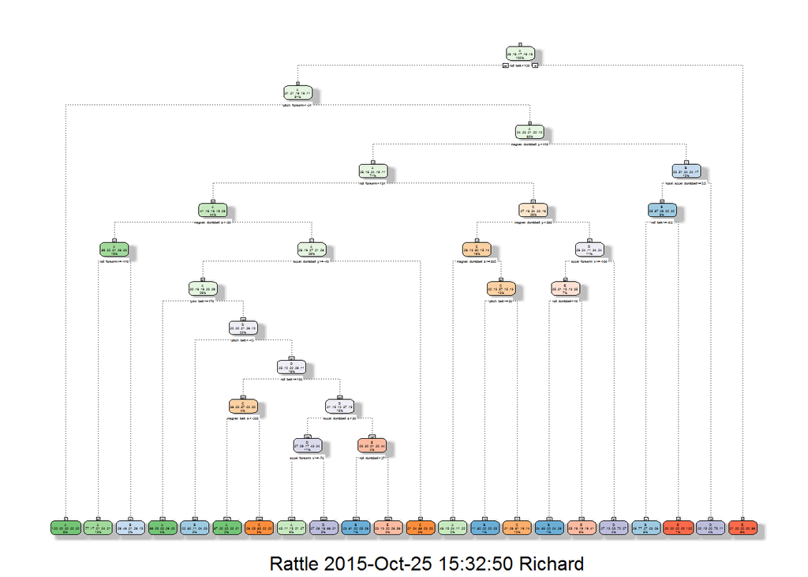

```r
knitr::opts_chunk$set(fig.path='Figs/', echo=FALSE)
fancyRpartPlot(modRpart)
```

### ML: randomForest

testing randomForest’s accuracy in predicting classe

```
## Confusion Matrix and Statistics
##
##           Reference
## Prediction    A    B    C    D    E
##          A 2230    4    0    0    0
##          B    1 1509   11    0    0
##          C    0    5 1357   10    0
##          D    0    0    0 1274    1
##          E    1    0    0    2 1441
##
## Overall Statistics
##
##                Accuracy : 0.9955
##                  95% CI : (0.9938, 0.9969)
##     No Information Rate : 0.2845
##     P-Value [Acc > NIR] : < 2.2e-16
##
##                   Kappa : 0.9944
##  Mcnemar's Test P-Value : NA
##
## Statistics by Class:
##
##                      Class: A Class: B Class: C Class: D Class: E
## Sensitivity            0.9991   0.9941   0.9920   0.9907   0.9993
## Specificity            0.9993   0.9981   0.9977   0.9998   0.9995
## Pos Pred Value         0.9982   0.9921   0.9891   0.9992   0.9979
## Neg Pred Value         0.9996   0.9986   0.9983   0.9982   0.9998
## Prevalence             0.2845   0.1935   0.1744   0.1639   0.1838
## Detection Rate         0.2842   0.1923   0.1730   0.1624   0.1837
## Detection Prevalence   0.2847   0.1939   0.1749   0.1625   0.1840
## Balanced Accuracy      0.9992   0.9961   0.9948   0.9953   0.9994
```

randomForest modelling shows a significant improvement in accuracy compared to rpart. Specifically, 0.9955 to 0.7261 respectively.

### Out of sample Error:

Out of sample Error using our best model, randomForest, is one minus the model’s accuracy. Thus, 0.0045

### Preparing the submission part:

Using the randomForest model to predict the test dataset.

Answers for problem ids 1 through 20: B A B A A E D B A A B C B A E E A B B B